Data Mining for BI - Unsupervised Learning

Kishore Chandramouli (M13471039), Anjana Ramji (M13480234 ), Aishwarya Kalyanaraman (M13255520), Siddharth Jain (M13439995), Parth Bhimani (M13383522), Dhwani Vora (M13513876), Kanchi Garg (M13482299), Prerna Parashar (M13515484)

# FIFA - 19 Data - Clustering

Data Mining for BI project to analyze and discover insights of the attributes of each player registered in the latest edition of FIFA 19 database using clustering techiques.

## Data

Detailed attributes for every player registered in the latest edition of FIFA 19 database:

- Original data from [Kaggle](https://www.kaggle.com/karangadiya/fifa19) ** There are 89 columns and 18207 rows

## Technologies and Techniques

- Python
- Anaconda Navigator
- Jupyter Notebook
- Google Colab
- Principal Component Analysis
- K-Means
- Hierarchical

## Python Libraries

- pandas
- pandas_profiling
- numpy
- pandasql
- stats
- sklearn
- sklearn.metrics.pairwise
- StandardScaler
- PCA
- KMeans
- matplotlib.pyplot
- mpl_toolkits.mplot3d
- seaborn
- ipywidgets
- seaborn

# K-Means Clustering

Loading main libraries and data

```python
import pandas as pd
import numpy as np
import matplotlib.pyplot as plt
%matplotlib inline
import pandas_profiling as pp
from sklearn.decomposition import PCA
from sklearn.preprocessing import StandardScaler
from sklearn.cluster import KMeans
import seaborn as sns
import sklearn.metrics as metrics
import sklearn.cluster as cluster
import scipy.cluster.hierarchy as shc
from sklearn.cluster import AgglomerativeClustering
```

```python
from google.colab import files
uploaded = files.upload()
data = pd.read_csv('data.csv')
```

Upload widget is only available when the cell has been executed in the current browser session. Please rerun this cell to enable.

```
Saving data.csv to data.csv
```

## Exploration and Cleaning

```python
data.columns
```

```
Index(['Unnamed: 0', 'ID', 'Name', 'Age', 'Photo', 'Nationality', 'Flag',
       'Overall', 'Potential', 'Club', 'Club Logo', 'Value', 'Wage', 'Special',
       'Preferred Foot', 'International Reputation', 'Weak Foot',
       'Skill Moves', 'Work Rate', 'Body Type', 'Real Face', 'Position',
       'Jersey Number', 'Joined', 'Loaned From', 'Contract Valid Until',
       'Height', 'Weight', 'LS', 'ST', 'RS', 'LW', 'LF', 'CF', 'RF', 'RW',
       'LAM', 'CAM', 'RAM', 'LM', 'LCM', 'CM', 'RCM', 'RM', 'LWB', 'LDM',
       'CDM', 'RDM', 'RWB', 'LB', 'LCB', 'CB', 'RCB', 'RB', 'Crossing',
       'Finishing', 'HeadingAccuracy', 'ShortPassing', 'Volleys', 'Dribbling',
       'Curve', 'FKAccuracy', 'LongPassing', 'BallControl', 'Acceleration',
       'SprintSpeed', 'Agility', 'Reactions', 'Balance', 'ShotPower',
       'Jumping', 'Stamina', 'Strength', 'LongShots', 'Aggression',
       'Interceptions', 'Positioning', 'Vision', 'Penalties', 'Composure',
       'Marking', 'StandingTackle', 'SlidingTackle', 'GKDiving', 'GKHandling',
       'GKKicking', 'GKPositioning', 'GKReflexes', 'Release Clause'],
      dtype='object')
```

```python
data.count().sort_values()
```

```
Loaned From     1264
LWB            16122
RS             16122
LW             16122
LF             16122
               ...
Age            18207
Name           18207
ID             18207
Value          18207
Unnamed: 0     18207
Length: 89, dtype: int64
```

```python
def getNumericalData(data, quality):
    numData = pd.DataFrame()
    for col in data.columns:
        if str(data[col].dtype) != "object":
            numData[col] = data[col]
    if quality and len(numData.columns) > 0:
        numData = numData.fillna(numData.mean())
    print(numData.shape)
    return numData;
```

```python
numdata = getNumericalData(data,True)
```

```
(18207, 44)
```

```python
numdata['Position'] = data['Position']
```

```python
numdata.columns
```

```
Index(['Unnamed: 0', 'ID', 'Age', 'Overall', 'Potential', 'Special',
       'International Reputation', 'Weak Foot', 'Skill Moves', 'Jersey Number',
       'Crossing', 'Finishing', 'HeadingAccuracy', 'ShortPassing', 'Volleys',
       'Dribbling', 'Curve', 'FKAccuracy', 'LongPassing', 'BallControl',
       'Acceleration', 'SprintSpeed', 'Agility', 'Reactions', 'Balance',
       'ShotPower', 'Jumping', 'Stamina', 'Strength', 'LongShots',
       'Aggression', 'Interceptions', 'Positioning', 'Vision', 'Penalties',
       'Composure', 'Marking', 'StandingTackle', 'SlidingTackle', 'GKDiving',
       'GKHandling', 'GKKicking', 'GKPositioning', 'GKReflexes', 'Position'],
      dtype='object')
```

```python
players = numdata.drop(['Unnamed: 0','ID','Special','Overall','Potential','Weak Foot', 'Skill Moves', 'Jersey Number'],axis=1)
```

```python
players = players.dropna().reset_index()
```

```python
players = players.drop(['index'],axis=1)
```

```python
players
```

|  | Age | International Reputation | Crossing | Finishing | HeadingAccuracy | ShortPassing | Volleys | Dribbling | Curve | FKAccuracy | LongPassing | BallControl | Acceleration | SprintSpeed | Agility | Reactions | Balance | ShotPower | Jumping | Stamina | Strength | LongShots | Aggression | Interceptions | Positioning | Vision | Penalties | Composure | Marking | … |
| --- | --- | --- | --- | --- | --- | --- | --- | --- | --- | --- | --- | --- | --- | --- | --- | --- | --- | --- | --- | --- | --- | --- | --- | --- | --- | --- | --- | --- | --- | --- |
| 0 | 31 | 5.0 | 84.0 | 95.0 | 70.0 | 90.0 | 86.0 | 97.0 | 93.0 | 94.0 | 87.0 | 96.0 | 91.0 | 86.0 | 91.0 | 95.0 | 95.0 | 85.0 | 68.0 | 72.0 | 59.0 | 94.0 | 48.0 | 22.0 | 94.0 | 94.0 | 75.0 | 96.0 | 33.0 | … |
| 1 | 33 | 5.0 | 84.0 | 94.0 | 89.0 | 81.0 | 87.0 | 88.0 | 81.0 | 76.0 | 77.0 | 94.0 | 89.0 | 91.0 | 87.0 | 96.0 | 70.0 | 95.0 | 95.0 | 88.0 | 79.0 | 93.0 | 63.0 | 29.0 | 95.0 | 82.0 | 85.0 | 95.0 | 28.0 | … |
| 2 | 26 | 5.0 | 79.0 | 87.0 | 62.0 | 84.0 | 84.0 | 96.0 | 88.0 | 87.0 | 78.0 | 95.0 | 94.0 | 90.0 | 96.0 | 94.0 | 84.0 | 80.0 | 61.0 | 81.0 | 49.0 | 82.0 | 56.0 | 36.0 | 89.0 | 87.0 | 81.0 | 94.0 | 27.0 | … |
| 3 | 27 | 4.0 | 17.0 | 13.0 | 21.0 | 50.0 | 13.0 | 18.0 | 21.0 | 19.0 | 51.0 | 42.0 | 57.0 | 58.0 | 60.0 | 90.0 | 43.0 | 31.0 | 67.0 | 43.0 | 64.0 | 12.0 | 38.0 | 30.0 | 12.0 | 68.0 | 40.0 | 68.0 | 15.0 | … |
| 4 | 27 | 4.0 | 93.0 | 82.0 | 55.0 | 92.0 | 82.0 | 86.0 | 85.0 | 83.0 | 91.0 | 91.0 | 78.0 | 76.0 | 79.0 | 91.0 | 77.0 | 91.0 | 63.0 | 90.0 | 75.0 | 91.0 | 76.0 | 61.0 | 87.0 | 94.0 | 79.0 | 88.0 | 68.0 | … |
| ... | ... | ... | ... | ... | ... | ... | ... | ... | ... | ... | ... | ... | ... | ... | ... | ... | ... | ... | ... | ... | ... | ... | ... | ... | ... | ... | ... | ... | ... | … |
| 18142 | 19 | 1.0 | 34.0 | 38.0 | 40.0 | 49.0 | 25.0 | 42.0 | 30.0 | 34.0 | 45.0 | 43.0 | 54.0 | 57.0 | 60.0 | 49.0 | 76.0 | 43.0 | 55.0 | 40.0 | 47.0 | 38.0 | 46.0 | 46.0 | 39.0 | 52.0 | 43.0 | 45.0 | 40.0 | … |
| 18143 | 19 | 1.0 | 23.0 | 52.0 | 52.0 | 43.0 | 36.0 | 39.0 | 32.0 | 20.0 | 25.0 | 40.0 | 41.0 | 39.0 | 38.0 | 40.0 | 52.0 | 41.0 | 47.0 | 43.0 | 67.0 | 42.0 | 47.0 | 16.0 | 46.0 | 33.0 | 43.0 | 42.0 | 22.0 | … |
| 18144 | 16 | 1.0 | 25.0 | 40.0 | 46.0 | 38.0 | 38.0 | 45.0 | 38.0 | 27.0 | 28.0 | 44.0 | 70.0 | 69.0 | 50.0 | 47.0 | 58.0 | 45.0 | 60.0 | 55.0 | 32.0 | 45.0 | 32.0 | 15.0 | 48.0 | 43.0 | 55.0 | 41.0 | 32.0 | … |
| 18145 | 17 | 1.0 | 44.0 | 50.0 | 39.0 | 42.0 | 40.0 | 51.0 | 34.0 | 32.0 | 32.0 | 52.0 | 61.0 | 60.0 | 52.0 | 21.0 | 71.0 | 64.0 | 42.0 | 40.0 | 48.0 | 34.0 | 33.0 | 22.0 | 44.0 | 47.0 | 50.0 | 46.0 | 20.0 | … |
| 18146 | 16 | 1.0 | 41.0 | 34.0 | 46.0 | 48.0 | 30.0 | 43.0 | 40.0 | 34.0 | 44.0 | 51.0 | 57.0 | 55.0 | 55.0 | 51.0 | 63.0 | 43.0 | 62.0 | 47.0 | 60.0 | 32.0 | 56.0 | 42.0 | 34.0 | 49.0 | 33.0 | 43.0 | 40.0 | … |

18147 rows × 37 columns

```python
players.shape
```

```
(18147, 37)
```

```python
Attacking = ['RF','ST','LF','RS','LS','CF']
Midfield =['LW','RCM','LCM','LDM','CAM','CDM','RM','LAM','LM','RDM','RW','CM','RAM']
Defense =['RCB','CB','LCB','LB','RB','RWB','LWB']
zone = []
for po in players.Position :
    if po in Attacking:
        zone.append('ATT')
    elif po in Midfield:
        zone.append('MID')
    elif po in Defense:
        zone.append('DEF')
    else:
        zone.append('GK')
players['Zone'] = zone
```

```python
players['Zone']
```

```
0        ATT
1        ATT
2        MID
3         GK
4        MID
        ...
18142    MID
18143    ATT
18144    ATT
18145    MID
18146    MID
Name: Zone, Length: 18147, dtype: object
```

```python
player_dat = players.drop(['Position','Zone'],axis=1).reset_index()
```

```python
player_dat = player_dat.drop(['index'],axis=1)
```

```python
player_dat
```

|  | Age | International Reputation | Crossing | Finishing | HeadingAccuracy | ShortPassing | Volleys | Dribbling | Curve | FKAccuracy | LongPassing | BallControl | Acceleration | SprintSpeed | Agility | Reactions | Balance | ShotPower | Jumping | Stamina | Strength | LongShots | Aggression | Interceptions | Positioning | Vision | Penalties | Composure | Marking | … |
| --- | --- | --- | --- | --- | --- | --- | --- | --- | --- | --- | --- | --- | --- | --- | --- | --- | --- | --- | --- | --- | --- | --- | --- | --- | --- | --- | --- | --- | --- | --- |
| 0 | 31 | 5.0 | 84.0 | 95.0 | 70.0 | 90.0 | 86.0 | 97.0 | 93.0 | 94.0 | 87.0 | 96.0 | 91.0 | 86.0 | 91.0 | 95.0 | 95.0 | 85.0 | 68.0 | 72.0 | 59.0 | 94.0 | 48.0 | 22.0 | 94.0 | 94.0 | 75.0 | 96.0 | 33.0 | … |
| 1 | 33 | 5.0 | 84.0 | 94.0 | 89.0 | 81.0 | 87.0 | 88.0 | 81.0 | 76.0 | 77.0 | 94.0 | 89.0 | 91.0 | 87.0 | 96.0 | 70.0 | 95.0 | 95.0 | 88.0 | 79.0 | 93.0 | 63.0 | 29.0 | 95.0 | 82.0 | 85.0 | 95.0 | 28.0 | … |
| 2 | 26 | 5.0 | 79.0 | 87.0 | 62.0 | 84.0 | 84.0 | 96.0 | 88.0 | 87.0 | 78.0 | 95.0 | 94.0 | 90.0 | 96.0 | 94.0 | 84.0 | 80.0 | 61.0 | 81.0 | 49.0 | 82.0 | 56.0 | 36.0 | 89.0 | 87.0 | 81.0 | 94.0 | 27.0 | … |
| 3 | 27 | 4.0 | 17.0 | 13.0 | 21.0 | 50.0 | 13.0 | 18.0 | 21.0 | 19.0 | 51.0 | 42.0 | 57.0 | 58.0 | 60.0 | 90.0 | 43.0 | 31.0 | 67.0 | 43.0 | 64.0 | 12.0 | 38.0 | 30.0 | 12.0 | 68.0 | 40.0 | 68.0 | 15.0 | … |
| 4 | 27 | 4.0 | 93.0 | 82.0 | 55.0 | 92.0 | 82.0 | 86.0 | 85.0 | 83.0 | 91.0 | 91.0 | 78.0 | 76.0 | 79.0 | 91.0 | 77.0 | 91.0 | 63.0 | 90.0 | 75.0 | 91.0 | 76.0 | 61.0 | 87.0 | 94.0 | 79.0 | 88.0 | 68.0 | … |
| ... | ... | ... | ... | ... | ... | ... | ... | ... | ... | ... | ... | ... | ... | ... | ... | ... | ... | ... | ... | ... | ... | ... | ... | ... | ... | ... | ... | ... | ... | … |
| 18142 | 19 | 1.0 | 34.0 | 38.0 | 40.0 | 49.0 | 25.0 | 42.0 | 30.0 | 34.0 | 45.0 | 43.0 | 54.0 | 57.0 | 60.0 | 49.0 | 76.0 | 43.0 | 55.0 | 40.0 | 47.0 | 38.0 | 46.0 | 46.0 | 39.0 | 52.0 | 43.0 | 45.0 | 40.0 | … |
| 18143 | 19 | 1.0 | 23.0 | 52.0 | 52.0 | 43.0 | 36.0 | 39.0 | 32.0 | 20.0 | 25.0 | 40.0 | 41.0 | 39.0 | 38.0 | 40.0 | 52.0 | 41.0 | 47.0 | 43.0 | 67.0 | 42.0 | 47.0 | 16.0 | 46.0 | 33.0 | 43.0 | 42.0 | 22.0 | … |
| 18144 | 16 | 1.0 | 25.0 | 40.0 | 46.0 | 38.0 | 38.0 | 45.0 | 38.0 | 27.0 | 28.0 | 44.0 | 70.0 | 69.0 | 50.0 | 47.0 | 58.0 | 45.0 | 60.0 | 55.0 | 32.0 | 45.0 | 32.0 | 15.0 | 48.0 | 43.0 | 55.0 | 41.0 | 32.0 | … |
| 18145 | 17 | 1.0 | 44.0 | 50.0 | 39.0 | 42.0 | 40.0 | 51.0 | 34.0 | 32.0 | 32.0 | 52.0 | 61.0 | 60.0 | 52.0 | 21.0 | 71.0 | 64.0 | 42.0 | 40.0 | 48.0 | 34.0 | 33.0 | 22.0 | 44.0 | 47.0 | 50.0 | 46.0 | 20.0 | … |
| 18146 | 16 | 1.0 | 41.0 | 34.0 | 46.0 | 48.0 | 30.0 | 43.0 | 40.0 | 34.0 | 44.0 | 51.0 | 57.0 | 55.0 | 55.0 | 51.0 | 63.0 | 43.0 | 62.0 | 47.0 | 60.0 | 32.0 | 56.0 | 42.0 | 34.0 | 49.0 | 33.0 | 43.0 | 40.0 | … |

18147 rows × 36 columns

**After carefully examining the dataset-**

- Removed the unnecessary columns and null values
- Segrated the dimenisons of the player in the zones

**Insights**

There is a large number of correlated variables in the original dataset, which is an ideal scenario to run a PCA and thus reduce the dimensions while maintaining the variance and the direction of the data.

## Principal Component Analysis

Selecting categorical and numeric variables

Only the numeric variables of the dataset will be used to perform the PCA. Then, the variables that you do not want to include in the analysis are discarded.

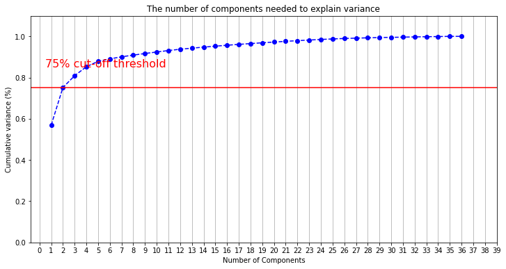

```python
pca = PCA().fit(player_dat)

%matplotlib inline
import matplotlib.pyplot as plt
plt.rcParams["figure.figsize"] = (12,6)

fig, ax = plt.subplots()
xi = np.arange(1, 37, step=1)
y = np.cumsum(pca.explained_variance_ratio_)

plt.ylim(0.0,1.1)
plt.plot(xi, y, marker='o', linestyle='--', color='b')

plt.xlabel('Number of Components')
plt.xticks(np.arange(0, 40, step=1)) #change from 0-based array index to 1-based human-readable label
plt.ylabel('Cumulative variance (%)')
plt.title('The number of components needed to explain variance')

plt.axhline(y=0.75, color='r', linestyle='-')
plt.text(0.5, 0.85, '75% cut-off threshold', color = 'red', fontsize=16)

ax.grid(axis='x')
plt.show()
```

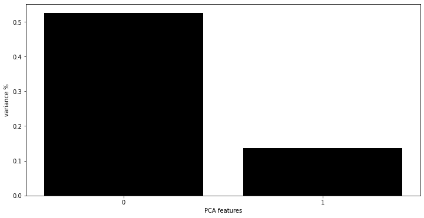

```python
X_std = StandardScaler().fit_transform(player_dat)
pca = PCA(n_components=2)
principalComponents = pca.fit_transform(X_std)
features = range(pca.n_components_)
plt.bar(features, pca.explained_variance_ratio_, color='black')
plt.xlabel('PCA features')
plt.ylabel('variance %')
plt.xticks(features)
PCA_components = pd.DataFrame(principalComponents)
```

```python
PCA_components = pd.concat([PCA_components, players[['Position','Zone']]], axis = 1)
```

```python
PCA_components
```

|  | 0 | 1 | Position | Zone |
| --- | --- | --- | --- | --- |
| 0 | -8.797322 | -5.230920 | RF | ATT |
| 1 | -8.579347 | -3.591391 | ST | ATT |
| 2 | -8.053379 | -4.991987 | LW | MID |
| 3 | 8.224188 | -1.824092 | GK | GK |
| 4 | -8.595288 | -1.610873 | RCM | MID |
| ... | ... | ... | ... | ... |
| 18142 | 2.418918 | -0.100703 | CM | MID |
| 18143 | 4.346935 | -0.894745 | ST | ATT |
| 18144 | 2.947315 | -2.614230 | ST | ATT |
| 18145 | 2.842637 | -2.540135 | RW | MID |
| 18146 | 2.430055 | 0.562613 | CM | MID |

18147 rows × 4 columns

```python
PCA_components.columns = ['PC1','PC2','Position','Zone']
```

## K-means Analysis

```python
x = PCA_components['PC1'].values
y = PCA_components['PC2'].values
train = np.array(list(zip(x, y)))
```

```python
# Calculating the Elbow
Nc = range(1, 20)
kmeans = [KMeans(n_clusters = i) for i in Nc]
score = [kmeans[i].fit(train).score(train) for i in range(len(kmeans))]
```

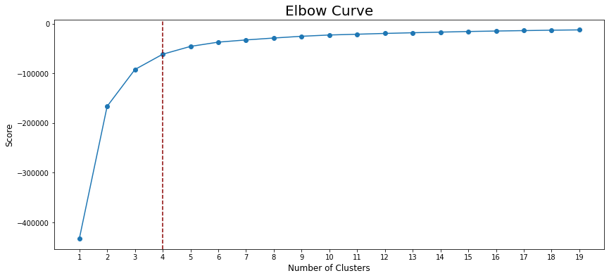

```python
# Plot the results
fig, ax0 = plt.subplots(figsize = (14, 6))
plt.plot(Nc, score, marker='o')
plt.axvline(x = 4, color = "#8b0000", linestyle = "--")
plt.xticks(np.arange(1, 20, 1))
plt.xlabel("Number of Clusters", fontsize = 12)
plt.ylabel("Score", fontsize = 12)
plt.title("Elbow Curve", fontsize = 20)
plt.show()
```

```python
# Calculates the K-Means for (x, y) dataset
def runKMeans(k_clusters):
    kmeans = KMeans(n_clusters = k_clusters, algorithm = "elkan", random_state = 0)
    kmeans = kmeans.fit(train)

    # Getting the cluster labels
    clusters = kmeans.predict(train)

    # Centroid values
    centroids = kmeans.cluster_centers_

    # Plotting K-Means result
    plotKMeansData(train, k_clusters, centroids, clusters)
```

```python
# Create scatter plot with K-Means data
def plotKMeansData(data, k_clusters, centroids, clusters):
    fig, ax1 = plt.subplots(figsize = (14, 14))

    # Plotting vars
    colors = ["#1f77b4", "#2ca02c", "#d62728", "#ff7f0e"]
    nData = len(data)

    # Create scatter plot
    for i in range(k_clusters):
        points = np.array([data[j] for j in range(nData) if clusters[j] == i])
        sns.scatterplot( ax=ax1,x = points[:, 0], y = points[:, 1], size = 5, color = colors[i],legend = False)
    plt.scatter(centroids[:, 0], centroids[:, 1], s = 20, color = "black", marker = "D")

    # Plot setup
    ax1.set_xlabel("PC 1", fontsize = 12)
    ax1.set_ylabel("PC 2", fontsize = 12)
    ax1.set_title("Players by Zones", fontsize = 20)
    ax1.grid()
```

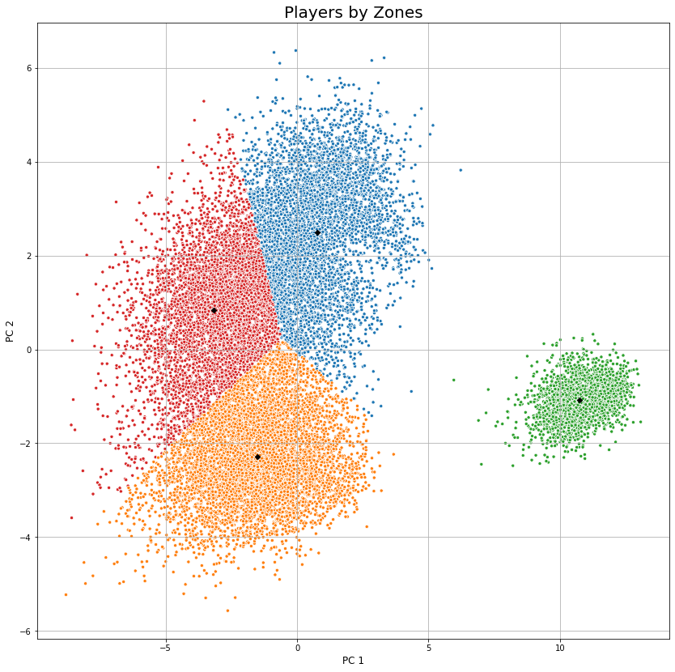

```python
runKMeans(k_clusters = 4)
```

```python
# Palette by positions dictionary
posPalette = dict()
posPalette["GK"] = "#dc3912"
posPalette["DEF"] = "#3366cc"
posPalette["MID"] = "#ff9900"
posPalette["ATT"]="#109618"
```

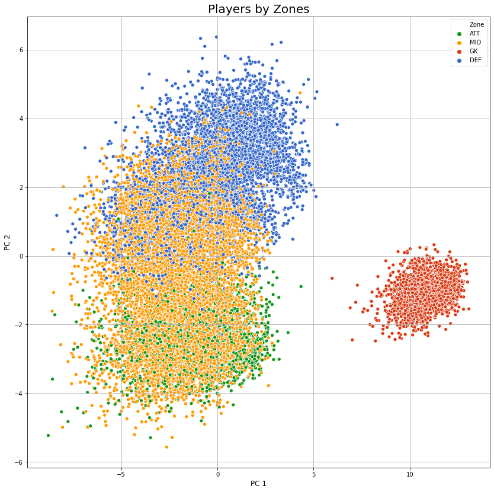

```python
# Create scatter plot with players label
fig, ax2 = plt.subplots(figsize = (14, 14))

# Create 2D scatter plot
plot = sns.scatterplot(ax = ax2, data = PCA_components, x = "PC1", y = "PC2", hue = "Zone", palette = posPalette,legend='brief')

# Plot setup
ax2.set_xlabel("PC 1", fontsize = 12)
ax2.set_ylabel("PC 2", fontsize = 12)
ax2.set_title("Players by Zones", fontsize = 20)
ax2.grid()
```

```python
X = train
kmeans = KMeans(n_clusters=4)
kmeans.fit(X)
```

```
KMeans(algorithm='auto', copy_x=True, init='k-means++', max_iter=300,
       n_clusters=4, n_init=10, n_jobs=None, precompute_distances='auto',
       random_state=None, tol=0.0001, verbose=0)
```

### Insights

By using PCA 1 & PCA 2 and K-Means algorithm, we created 2 charts.

# Hierarchical Clustering

## Dendrogram Graph

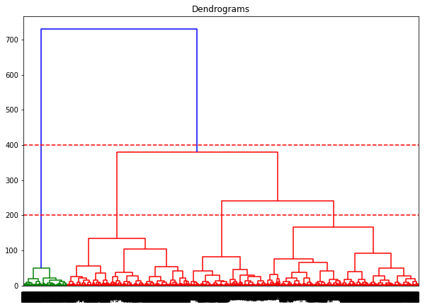

```python
import scipy.cluster.hierarchy as shc
plt.figure(figsize=(10, 7))
plt.title("Dendrograms")
dend = shc.dendrogram(shc.linkage(train, method='ward'))
plt.axhline(y=200, color='r', linestyle='--')
plt.axhline(y=400, color='r', linestyle='--')
```

## Agglomerative Clustering

```python
def plotHierData(data, h_clusters, clusters):
    fig, ax1 = plt.subplots(figsize = (14, 14))

    # Plotting vars
    colors = ["#1f77b4", "#2ca02c", "#d62728", "#ff7f0e"]
    nData = len(data)

    # Create scatter plot
    for i in range(h_clusters):
        points = np.array([data[j] for j in range(nData) if clusters[j] == i])
        sns.scatterplot( ax=ax1,x = points[:, 0], y = points[:, 1], size = 5, color = colors[i],legend = False)

    # Plot setup
    ax1.set_xlabel("PC 1", fontsize = 12)
    ax1.set_ylabel("PC 2", fontsize = 12)
    ax1.set_title("Players by Zones", fontsize = 20)
    ax1.grid()
```

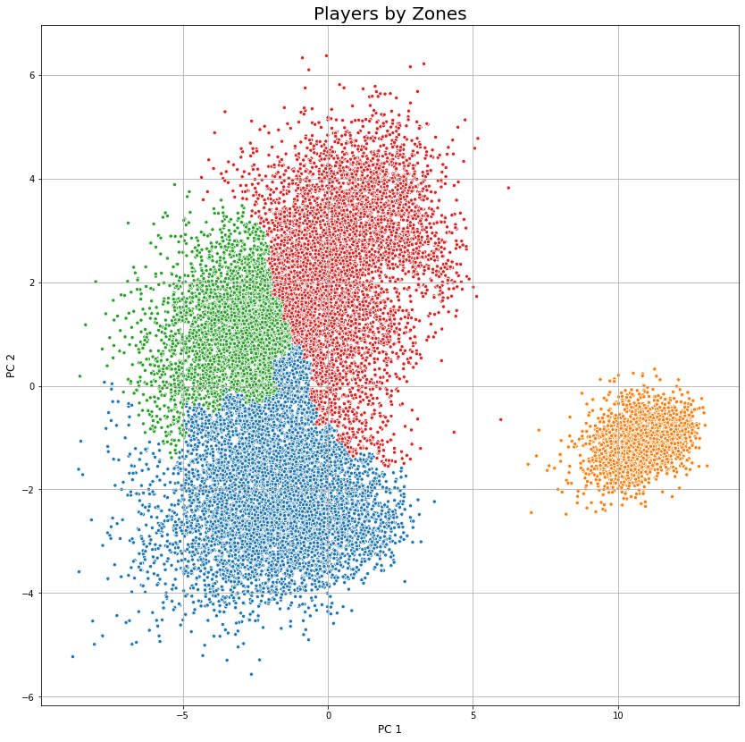

```python
h_clusters = 4
hiercluster = AgglomerativeClustering(n_clusters=4, affinity='euclidean', linkage='ward')

# Getting the cluster labels
hiercluster = hiercluster.fit_predict(train)

# Plotting H-Means result
plotHierData(train, h_clusters, hiercluster)
```

## Comparison

```python
data = PCA_components
data['hier_cluster'] = hiercluster
data['k_cluster'] = kmeans.predict(train)
```

```python
pd.crosstab(data['hier_cluster'], data['Zone'])
```

| Zone hier_cluster | ATT | DEF | GK | MID |
| --- | --- | --- | --- | --- |
| 0 | 2501 | 157 | 0 | 4316 |
| 1 | 29 | 1472 | 0 | 2024 |
| 2 | 137 | 4237 | 1 | 1249 |
| 3 | 0 | 0 | 2024 | 0 |

```python
pd.crosstab(data['k_cluster'], data['Zone'])
```

| Zone k_cluster | ATT | DEF | GK | MID |
| --- | --- | --- | --- | --- |
| 0 | 201 | 1881 | 0 | 3001 |
| 1 | 0 | 0 | 2025 | 0 |
| 2 | 46 | 3929 | 0 | 904 |
| 3 | 2420 | 56 | 0 | 3684 |

```python
labels=cluster.KMeans(n_clusters=4,random_state=200).fit(player_dat).labels_
print(metrics.silhouette_score(player_dat,labels,metric="euclidean",sample_size=10000,random_state=200))
```

```
0.2904235922527936
```

```python
metrics.silhouette_score(train, hiercluster)
```

```
0.42065024696020425
```

# Conclusion

We can see the clusters formed by using different clustering algorithms - K-means and Hierarchical algorithms respectively .

We can also see the silhouette scores for each.